# Projekt Ekonometria

# Testujemy normalność reszt za pomocą testu shapiro-wilka

```r
shapiro.test(model$residuals)
```

```
##
##  Shapiro-Wilk normality test
##
## data:  model$residuals
## W = 0.94482, p-value < 2.2e-16
```

# test jarque-bera

```r
library(tseries)
jarque.bera.test(model$residuals)
```

```
##
##  Jarque Bera Test
##
## data:  model$residuals
## X-squared = 1259.2, df = 2, p-value < 2.2e-16
```

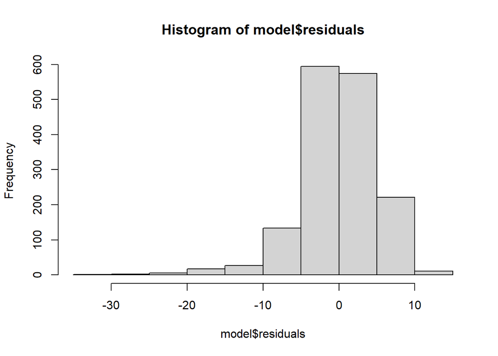

```r
hist(model$residuals)
```

Błędy szacunku nie pochodzą z rozkładu normalnego, oba testy odrzuciły h0 o normalności rozkładu. Na ten rezultat wpływ może mieć wiele czynników. Jednym z nich jest heteroskadastyczność modelu, którą za chwile zaprezentujemy. Wariancja reszt nie jest stała, zmienia się w zależności od wartości zmiennych niezależnych, może to prowadzić do nienormalności reszt. Nie wykluczone jest to iż model posiada niewłaściwą specyfikację, model liniowy wyestymowany za pomocą MNK, może być niedopasowany do danych. Występuje wiele wartości odstających, dlatego skośność lewostronną.

# Autokorelacja

```r
library(lmtest)
dwtest(model)
```

```
##
##  Durbin-Watson test
##
## data:  model
## DW = 2.168, p-value = 0.9996
## alternative hypothesis: true autocorrelation is greater than 0
```

Nasz model nie spełnia założeń testu DURBINA-WATSONA (Założenia dla testu Durbina-Watsona: - model ekonometryczny posiada wyraz wolny, - składnik losowy ma rozkład normalny, - w modelu nie występuje opóźniona zmienna objaśniana jako zmienna objaśniająca). Jednak pomijając tą niezgodność wyliczyliśmy test DURBINA-WATSONA, który nie odrzucił H0, czyli autokorelacja jest statystycznie nieistotna.

# Współliniowość

Współliniowość to sytuacja, w której dwie lub więcej zmiennych niezależnych w modelu statystycznym są silnie skorelowane ze sobą. W takim przypadku, trudno jest określić, jak każda z tych zmiennych indywidualnie wpływa na zmienną zależną, ponieważ zmiany w jednej z nich są zazwyczaj związane ze zmianami w innych.

Wysoka współliniowość może prowadzić do różnych problemów w modelowaniu statystycznym, w tym:

1. Niemożność jednoznacznego ustalenia wpływu poszczególnych zmiennych na zmienną zależną.
2. Zwiększenie wariancji estymacji współczynników regresji, co prowadzi do mniej stabilnych i mniej wiarygodnych wyników.
3. Problem interpretacji wyników modelu, ze względu na trudność w oddzielaniu efektów poszczególnych zmiennych.

Zasada ogólna mówi, że jeśli VIF przekracza 5 lub 10, to współliniowość może być problemem. W takim przypadku, możemy zdecydować się na usunięcie jednej lub więcej zmiennych, które są silnie skorelowane.

```r
library(car)
vif(model)
```

```
##             freedix                myis log(GDP_per_capita)
##            1.518794            2.401523            2.388199
```

Żadna wartość nie przekracza wartości 5, zatem nie usuwamy zmiennych.